# EGRMGMT 590.10 Homework 2

*Due at 6:15pm ET on Thursday, February 7*

## Instructions

- Make sure you have pandas, NumPy, SciPy, Matplotlib, seaborn, and scikit-learn installed before working on the assignment.
- There are 12 exercises all of which require coding. Your grades are based on the accuracy of the results, not the code execution speed.
  - Exercise 1 to 6, 8, and 10 to 12: each is worth 0.5 points.
  - Exercise 7: 1 point.
  - Exercise 9: 4 points.
- Exercises are dependent on prior exercises. Please work on them in the pre-determined order.
- Submit the .ipynb and .py files to Sakai before 6:15pm ET on Thursday, February 7.
- Assignments handed in late will lose 1 point every 24-hour window after 6:15pm ET on Thursday, February 7.

## Dataset

**Dataset Information:**

The dataset is from the results of a chemical analysis of wines grown in the same region in Italy but derived from three different cultivars. The first variable in the dataset indicates the cultivar. The remaining 13 variables are the quantities of 13 constituents found in each of the three types of wines.

1. Cultivar
2. Alcohol
3. Malic acid
4. Ash
5. Alcalinity of ash
6. Magnesium
7. Total phenols
8. Flavanoids
9. Nonflavanoid phenols
10. Proanthocyanins
11. Color intensity
12. Hue
13. OD280/OD315 of diluted wines
14. Proline

**Dataset Source:** https://archive.ics.uci.edu/ml/datasets/wine

## Exercises

**Exercise Overview**

- We'll conduct cluster analysis using the 13 variables (i.e. excluding 'Cultivar') in the dataset and group wines into natural clusters.

### Exercise 1

- Use the read_csv() function of pandas to read the wine dataset directly from its URL (https://archive.ics.uci.edu/ml/machine-learning-databases/wine/wine.data) to a pandas DataFrame df
- Display the first five rows of data in df

```python
import pandas as pd
import numpy  as np
import matplotlib.pyplot as plt
import seaborn as sns; sns.set()
import copy as copy
cluster_num = 3
df = pd.read_csv('https://archive.ics.uci.edu/ml/machine-learning-databases/wine/wine.data')
df.head()
```

|  | 1 | 14.23 | 1.71 | 2.43 | 15.6 | 127 | 2.8 | 3.06 | .28 | 2.29 | 5.64 | 1.04 | 3.92 | 1065 |
| --- | --- | --- | --- | --- | --- | --- | --- | --- | --- | --- | --- | --- | --- | --- |
| 0 | 1 | 13.20 | 1.78 | 2.14 | 11.2 | 100 | 2.65 | 2.76 | 0.26 | 1.28 | 4.38 | 1.05 | 3.40 | 1050 |
| 1 | 1 | 13.16 | 2.36 | 2.67 | 18.6 | 101 | 2.80 | 3.24 | 0.30 | 2.81 | 5.68 | 1.03 | 3.17 | 1185 |
| 2 | 1 | 14.37 | 1.95 | 2.50 | 16.8 | 113 | 3.85 | 3.49 | 0.24 | 2.18 | 7.80 | 0.86 | 3.45 | 1480 |
| 3 | 1 | 13.24 | 2.59 | 2.87 | 21.0 | 118 | 2.80 | 2.69 | 0.39 | 1.82 | 4.32 | 1.04 | 2.93 | 735 |
| 4 | 1 | 14.20 | 1.76 | 2.45 | 15.2 | 112 | 3.27 | 3.39 | 0.34 | 1.97 | 6.75 | 1.05 | 2.85 | 1450 |

### Exercise 2

- Rename the columns of df using a list ['Cultivar', 'Alcohol', 'MalicAcid', 'Ash', 'AlcalinityAsh', 'Magnesium', 'TotPhenols', 'Flavanoids', 'NonflavanoidPhenols', 'Proanthocyanins', 'ColorIntensity', 'Hue', 'OD280/OD315Diluted', 'Proline']
- Display the last five rows of data in df

```python
df.columns = ['Cultivar', 'Alcohol', 'MalicAcid', 'Ash', 'AlcalinityAsh', 'Magnesium', 'TotPhenols', 'Flavanoids', 'NonflavanoidPhenols', 'Proanthocyanins', 'ColorIntensity', 'Hue', 'OD280/OD315Diluted', 'Proline']
df.tail()
```

|  | Cultivar | Alcohol | MalicAcid | Ash | AlcalinityAsh | Magnesium | TotPhenols | Flavanoids | NonflavanoidPhenols | Proanthocyanins | ColorIntensity | Hue | OD280/OD315Diluted | Proline |
| --- | --- | --- | --- | --- | --- | --- | --- | --- | --- | --- | --- | --- | --- | --- |
| 172 | 3 | 13.71 | 5.65 | 2.45 | 20.5 | 95 | 1.68 | 0.61 | 0.52 | 1.06 | 7.7 | 0.64 | 1.74 | 740 |
| 173 | 3 | 13.40 | 3.91 | 2.48 | 23.0 | 102 | 1.80 | 0.75 | 0.43 | 1.41 | 7.3 | 0.70 | 1.56 | 750 |
| 174 | 3 | 13.27 | 4.28 | 2.26 | 20.0 | 120 | 1.59 | 0.69 | 0.43 | 1.35 | 10.2 | 0.59 | 1.56 | 835 |
| 175 | 3 | 13.17 | 2.59 | 2.37 | 20.0 | 120 | 1.65 | 0.68 | 0.53 | 1.46 | 9.3 | 0.60 | 1.62 | 840 |
| 176 | 3 | 14.13 | 4.10 | 2.74 | 24.5 | 96 | 2.05 | 0.76 | 0.56 | 1.35 | 9.2 | 0.61 | 1.60 | 560 |

### Exercise 3

- Use the seaborn library to create a matrix of scatter plots for all the variables in df, excluding 'Cultivar'
- Set the diagnal subplots as histograms for univariate distributions

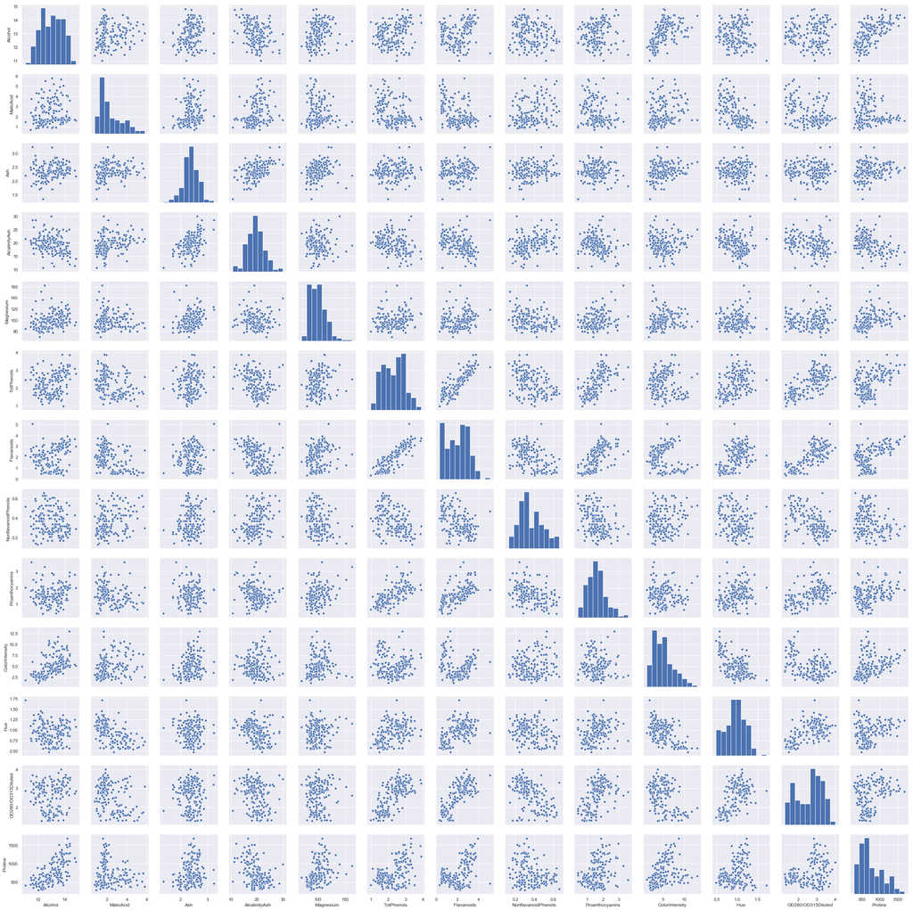

```python
>>> import seaborn as sns; sns.set()
>>> import matplotlib.pyplot as plt

df_data = df.drop(columns = 'Cultivar')
df_data
sns.pairplot(data = df_data)
plt.show()
```

### Exercise 4

- Create a new pandas DataFrame df_standardized which has the standardized values of each column in df, excluding 'Cultivar'.
- Column names of df_standardized match corresponding columns in df
- Display the summary statistics (i.e. count, mean, std, min, 1st/2nd/3rd quartile, and max) by column for df_standardized

```python
df_standardized = (df_data - df_data.mean()) / df_data.std()
df_standardized.describe()
```

|  | Alcohol | MalicAcid | Ash | AlcalinityAsh | Magnesium | TotPhenols | Flavanoids | NonflavanoidPhenols | Proanthocyanins | ColorIntensity | Hue | OD280/OD315Diluted | Proline |
| --- | --- | --- | --- | --- | --- | --- | --- | --- | --- | --- | --- | --- | --- |
| count | 1.770000e+02 | 1.770000e+02 | 1.770000e+02 | 1.770000e+02 | 1.770000e+02 | 1.770000e+02 | 1.770000e+02 | 1.770000e+02 | 1.770000e+02 | 1.770000e+02 | 1.770000e+02 | 1.770000e+02 | 1.770000e+02 |
| mean | 8.363680e-15 | 1.844099e-16 | -3.651818e-15 | -1.517932e-16 | -7.276038e-17 | -2.621883e-16 | 6.435530e-16 | -3.399666e-16 | -2.093115e-15 | -6.435530e-16 | 2.344640e-15 | 1.979584e-15 | 1.586929e-16 |
| std | 1.000000e+00 | 1.000000e+00 | 1.000000e+00 | 1.000000e+00 | 1.000000e+00 | 1.000000e+00 | 1.000000e+00 | 1.000000e+00 | 1.000000e+00 | 1.000000e+00 | 1.000000e+00 | 1.000000e+00 | 1.000000e+00 |
| min | -2.427858e+00 | -1.429345e+00 | -3.657687e+00 | -2.672889e+00 | -2.087451e+00 | -2.094706e+00 | -1.685709e+00 | -1.863706e+00 | -2.059242e+00 | -1.623958e+00 | -2.081668e+00 | -1.892339e+00 | -1.483391e+00 |
| 25% | -7.834640e-01 | -6.610180e-01 | -5.676819e-01 | -6.945143e-01 | -8.175219e-01 | -8.815494e-01 | -8.245532e-01 | -7.405873e-01 | -5.895412e-01 | -7.936523e-01 | -7.723963e-01 | -9.563055e-01 | -7.783692e-01 |
| 50% | 6.964280e-02 | -4.197989e-01 | -2.238688e-02 | -5.080573e-03 | -1.120057e-01 | 9.216813e-02 | 1.066969e-01 | -1.790282e-01 | -6.464788e-02 | -1.612437e-01 | 1.316669e-02 | 2.491923e-01 | -2.321364e-01 |
| 75% | 8.362026e-01 | 6.790880e-01 | 7.046732e-01 | 5.944270e-01 | 5.229589e-01 | 8.104843e-01 | 8.376782e-01 | 6.231993e-01 | 6.352099e-01 | 4.926755e-01 | 7.114449e-01 | 8.023031e-01 | 7.618803e-01 |
| max | 2.270411e+00 | 3.091279e+00 | 3.140324e+00 | 3.142334e+00 | 4.403298e+00 | 2.534443e+00 | 3.060662e+00 | 2.388100e+00 | 3.487130e+00 | 3.418103e+00 | 3.286346e+00 | 1.979436e+00 | 2.969042e+00 |

```python
df_standardized.head()
```

|  | Alcohol | MalicAcid | Ash | AlcalinityAsh | Magnesium | TotPhenols | Flavanoids | NonflavanoidPhenols | Proanthocyanins | ColorIntensity | Hue | OD280/OD315Diluted | Proline |
| --- | --- | --- | --- | --- | --- | --- | --- | --- | --- | --- | --- | --- | --- |
| 0 | 0.255101 | -0.500205 | -0.822153 | -2.493037 | 0.029098 | 0.571046 | 0.737544 | -0.820810 | -0.537052 | -0.290307 | 0.405948 | 1.128497 | 0.968306 |
| 1 | 0.205645 | 0.017969 | 1.104556 | -0.274859 | 0.099649 | 0.810484 | 1.218189 | -0.499919 | 2.139904 | 0.268966 | 0.318663 | 0.802303 | 1.397035 |
| 2 | 1.701673 | -0.348327 | 0.486555 | -0.814416 | 0.946269 | 2.486555 | 1.468525 | -0.981256 | 1.037628 | 1.181011 | -0.423257 | 1.199408 | 2.333888 |
| 3 | 0.304556 | 0.223452 | 1.831616 | 0.444550 | 1.299027 | 0.810484 | 0.667450 | 0.222086 | 0.407756 | -0.316119 | 0.362306 | 0.461927 | -0.032063 |
| 4 | 1.491488 | -0.518073 | 0.304790 | -1.294022 | 0.875717 | 1.560726 | 1.368391 | -0.179028 | 0.670203 | 0.729291 | 0.405948 | 0.348469 | 2.238614 |

### Exercise 5

- Use sklearn's KMeans to conduct k-means clustering with k = 3 for df_standardized using randomly chosen initial centroids
- Assign cluster membership to each instance in df_standardized. Save the cluster membership labels of all the instances to a ndarray y_pred1

```python
from sklearn.cluster import KMeans
km = KMeans(n_clusters = 3, init = 'random').fit(df_standardized)
y_pred1 = km.labels_
df_std_6 = copy.deepcopy(df_standardized)
df_std_6['Cluster'] = y_pred1
print(y_pred1)
df_standardized
#df_standardized.index = km.labels_
#for x in range(km.labels_):
    #y_pred1[x][0] = km.labels_[x]
```

[output not shown]

|  | Alcohol | MalicAcid | Ash | AlcalinityAsh | Magnesium | TotPhenols | Flavanoids | NonflavanoidPhenols | Proanthocyanins | ColorIntensity | Hue | OD280/OD315Diluted | Proline |
| --- | --- | --- | --- | --- | --- | --- | --- | --- | --- | --- | --- | --- | --- |
| 0 | 0.255101 | -0.500205 | -0.822153 | -2.493037 | 0.029098 | 0.571046 | 0.737544 | -0.820810 | -0.537052 | -0.290307 | 0.405948 | 1.128497 | 0.968306 |
| 1 | 0.205645 | 0.017969 | 1.104556 | -0.274859 | 0.099649 | 0.810484 | 1.218189 | -0.499919 | 2.139904 | 0.268966 | 0.318663 | 0.802303 | 1.397035 |
| 2 | 1.701673 | -0.348327 | 0.486555 | -0.814416 | 0.946269 | 2.486555 | 1.468525 | -0.981256 | 1.037628 | 1.181011 | -0.423257 | 1.199408 | 2.333888 |
| 3 | 0.304556 | 0.223452 | 1.831616 | 0.444550 | 1.299027 | 0.810484 | 0.667450 | 0.222086 | 0.407756 | -0.316119 | 0.362306 | 0.461927 | -0.032063 |
| 4 | 1.491488 | -0.518073 | 0.304790 | -1.294022 | 0.875717 | 1.560726 | 1.368391 | -0.179028 | 0.670203 | 0.729291 | 0.405948 | 0.348469 | 2.238614 |
| 5 | 1.726401 | -0.419799 | 0.304790 | -1.473874 | -0.253109 | 0.331607 | 0.497221 | -0.499919 | 0.687699 | 0.083976 | 0.275021 | 1.383778 | 1.730491 |
| 6 | 1.318393 | -0.169646 | 0.886438 | -0.574613 | 1.510682 | 0.491233 | 0.487208 | -0.419696 | -0.589541 | -0.002066 | 0.449591 | 1.383778 | 1.746370 |
| 7 | 2.270411 | -0.625282 | -0.713094 | -1.653727 | -0.182557 | 0.810484 | 0.957839 | -0.580142 | 0.687699 | 0.062466 | 0.536875 | 0.348469 | 0.952427 |
| 8 | 1.071116 | -0.884369 | -0.349564 | -1.054219 | -0.112006 | 1.097811 | 1.128068 | -1.141701 | 0.460245 | 0.931490 | 0.231379 | 1.341231 | 0.952427 |
| 9 | 1.367849 | -0.160712 | -0.240505 | -0.454711 | 0.381856 | 1.049923 | 1.298296 | -1.141701 | 1.387557 | 0.299081 | 1.278796 | 0.802303 | 2.429161 |
| 10 | 1.392577 | -0.768227 | -0.167799 | -0.814416 | -0.323661 | -0.147271 | 0.407100 | -0.820810 | -0.029655 | -0.023576 | 0.929657 | 0.305922 | 1.698733 |
| 11 | 0.935113 | -0.544876 | 0.159378 | -1.054219 | -0.746970 | 0.491233 | 0.737544 | -0.580142 | 0.390260 | 0.234549 | 0.842372 | 0.419380 | 1.825764 |
| 12 | 2.171500 | -0.544876 | 0.086672 | -2.433086 | -0.605867 | 1.289362 | 1.668794 | 0.542977 | 2.139904 | 0.148508 | 1.278796 | 0.178281 | 1.285883 |
| 13 | 1.714037 | -0.419799 | 0.050319 | -2.253234 | 0.170201 | 1.608613 | 1.618727 | -0.580142 | 2.402351 | 1.051948 | 1.060584 | 0.561204 | 2.546664 |
| 14 | 0.786747 | -0.473403 | 1.213615 | -0.694514 | 0.875717 | 0.890297 | 0.887745 | -0.499919 | -0.222116 | 0.965906 | 1.409723 | 0.391016 | 1.794006 |
| 15 | 1.615126 | -0.375129 | 1.286321 | 0.144796 | 1.440130 | 0.810484 | 1.118055 | -0.259251 | 0.670203 | 0.492675 | 0.493233 | 0.064822 | 1.698733 |
| 16 | 1.034024 | -0.687820 | 0.922791 | 0.144796 | 1.087372 | 1.049923 | 1.378404 | 0.302308 | 0.232792 | 0.664759 | 0.755087 | -0.048637 | 1.222367 |
| 17 | 1.479124 | -0.669952 | 0.413849 | -0.904342 | 0.593511 | 1.608613 | 1.909116 | -0.339474 | 0.477742 | 1.568200 | 1.191511 | 0.305922 | 2.969042 |
| 18 | 0.799111 | 0.679088 | 0.704673 | -1.294022 | 1.157924 | 0.650858 | 1.007907 | -1.542815 | 0.127813 | 0.019445 | 0.013167 | 1.071767 | 0.317272 |
| 19 | 1.318393 | -0.634216 | -0.313211 | -1.054219 | 1.863440 | 1.129736 | 1.148095 | -0.981256 | 0.897657 | 0.256060 | 0.580518 | 1.568149 | 0.110847 |
| 20 | -0.078724 | 1.304471 | 1.031850 | -0.274859 | 0.170201 | 0.187944 | 0.387073 | -0.901033 | 0.687699 | -0.238681 | 0.318663 | 1.298685 | 0.079089 |
| 21 | 0.885658 | -0.428733 | -0.022387 | -0.874367 | 0.099649 | 0.507195 | 0.857705 | -0.740587 | 0.180302 | -0.539828 | 0.667802 | 1.979436 | 0.920669 |
| 22 | -0.177635 | -0.661018 | 0.559261 | -0.514662 | -0.323661 | 0.299682 | 0.347020 | -0.820810 | -0.222116 | -0.483901 | 0.580518 | 1.454690 | 0.857153 |
| 23 | 0.626017 | -0.473403 | 0.886438 | 0.144796 | -0.253109 | 0.379495 | 0.587342 | -0.660365 | 0.127813 | -0.660287 | 0.711445 | 1.724154 | 0.317272 |
| 24 | 0.069643 | -0.258986 | 3.103971 | 1.643565 | 1.722337 | 0.539120 | 0.657436 | 0.863867 | 0.582721 | -0.634475 | 0.755087 | 0.844850 | 0.269636 |
| 25 | 0.490014 | -0.509139 | 0.922791 | -1.024244 | -0.464764 | 0.890297 | 0.917786 | -0.179028 | -0.239612 | -0.109618 | -0.161403 | 0.873215 | 1.428792 |
| 26 | 0.378739 | -0.553810 | -0.822153 | -0.754465 | -0.394212 | 0.171981 | 0.166778 | -0.740587 | -0.414577 | -0.475297 | 0.275021 | 0.235010 | 1.714612 |
| 27 | 1.083480 | -0.392997 | 1.577145 | -0.035056 | 0.522959 | 1.049923 | 0.947826 | 0.061640 | 0.302777 | -0.238681 | 1.278796 | 1.128497 | 0.539576 |
| 28 | 1.268938 | -0.589546 | -0.567682 | -1.054219 | -0.253109 | 0.571046 | 0.306966 | -0.820810 | 0.687699 | -0.152639 | 0.362306 | 1.397961 | 0.920669 |
| 29 | 0.910386 | -0.750358 | 1.213615 | 0.894181 | 0.099649 | 1.129736 | 1.228202 | -0.580142 | 1.387557 | 0.277570 | 1.016942 | 0.149916 | 1.714612 |
| ... | ... | ... | ... | ... | ... | ... | ... | ... | ... | ... | ... | ... | ... |
| 147 | 0.403467 | 0.804165 | 0.050319 | 0.594427 | -0.535315 | -0.578260 | -1.265145 | 0.703422 | -0.589541 | 1.447742 | -1.776171 | -1.395958 | -0.302003 |
| 148 | 0.106734 | 1.393811 | -0.022387 | 0.594427 | 0.946269 | -1.408315 | -0.634298 | -0.179028 | -0.782002 | 1.869347 | -1.688886 | -1.807245 | -0.619581 |
| 149 | 0.626017 | 0.696956 | 0.922791 | 1.343812 | 1.651785 | -1.424277 | -0.454056 | -1.141701 | -0.589541 | 1.525179 | -1.601602 | -1.849792 | -0.778369 |
| 150 | -0.251818 | 0.294924 | 0.413849 | 0.744304 | 0.875717 | -1.296576 | -0.664338 | -0.981256 | -0.572045 | 2.471641 | -2.081668 | -1.608693 | -0.841885 |
| 151 | 0.143826 | -0.392997 | 1.395380 | 1.793442 | 1.157924 | -0.147271 | -0.744446 | -0.820810 | -0.047151 | 0.879864 | -1.514317 | -1.807245 | -1.016552 |
| 152 | 0.292192 | 0.857769 | -0.313211 | -0.304834 | -0.112006 | -0.785774 | -1.195051 | 1.986986 | 0.495238 | 2.351182 | -1.732529 | -1.551963 | -0.222609 |
| 153 | -0.511459 | -0.937973 | -0.967565 | 0.144796 | 0.240752 | -1.296576 | -1.445387 | 1.345204 | -0.327095 | 1.094969 | -1.645244 | -1.495234 | -0.333761 |
| 154 | 0.218009 | 2.546302 | -0.167799 | 0.744304 | -0.464764 | -0.881549 | -1.395319 | 1.986986 | -0.064648 | 1.224032 | -1.557959 | -1.594510 | -0.063820 |
| 155 | 1.046388 | 1.590360 | 0.050319 | -0.005081 | -0.746970 | -0.785774 | -1.195051 | 0.944090 | -0.047151 | 1.701565 | -1.688886 | -1.367593 | -0.841885 |
| 156 | -0.672189 | 0.616550 | 0.995497 | 2.243073 | -0.182557 | -0.626148 | -1.445387 | 2.147431 | -0.782002 | 1.051948 | -1.252462 | -1.239952 | 0.428424 |
| 157 | 1.664582 | -0.589546 | 1.213615 | 1.643565 | -0.112006 | 0.810484 | -0.714405 | 1.345204 | 1.947443 | 3.418103 | -1.688886 | -0.913759 | -0.270246 |
| 158 | 0.601289 | -0.598480 | 0.995497 | 0.894181 | -0.746970 | 0.491233 | -0.924688 | 1.264981 | 1.230089 | 2.880341 | -1.688886 | -1.169040 | -0.397277 |
| 159 | -0.783464 | 1.331273 | 0.050319 | 0.444550 | -0.817522 | 0.012355 | -1.104930 | 1.104536 | -0.956967 | 1.116480 | -1.732529 | -1.452687 | -0.714854 |
| 160 | 0.860930 | 0.822033 | 0.631967 | 0.144796 | 0.522959 | -0.737886 | -1.465413 | 1.104536 | -1.376881 | 0.355008 | 0.013167 | -1.112311 | -0.206730 |
| 161 | -0.177635 | 0.830967 | 0.777379 | 0.744304 | 0.452407 | -1.025213 | -1.425360 | 1.906763 | -1.096938 | 0.225945 | -0.379615 | -0.701024 | -0.556065 |
| 162 | -0.041632 | 0.991779 | -0.058740 | -0.304834 | 0.452407 | -1.440240 | -1.325225 | 0.302308 | -1.131931 | 0.096882 | -1.208820 | -1.211587 | -0.222609 |
| 163 | 0.972205 | 0.375331 | -0.240505 | 0.744304 | -0.676419 | -1.504090 | -1.345252 | 0.382531 | -0.974463 | 1.946785 | -1.121535 | -1.310864 | -0.413155 |
| 164 | 0.910386 | 1.804777 | -0.385917 | 0.894181 | -0.817522 | -1.615828 | -1.555534 | 1.264981 | -0.764506 | 0.673364 | -0.772396 | -1.211587 | -0.714854 |
| 165 | 0.564197 | 1.215130 | 0.850085 | 1.044058 | 0.805165 | -0.945400 | -1.104930 | 0.542977 | -0.222116 | 2.420016 | -0.466900 | -1.481052 | -0.159094 |
| 166 | -0.214726 | 0.920307 | -0.240505 | -0.005081 | -0.817522 | -1.296576 | -1.365279 | 0.302308 | -1.079442 | 2.239328 | -1.034251 | -1.211587 | -0.190851 |
| 167 | 0.724928 | 0.214518 | 1.177262 | 1.493688 | 0.381856 | -1.184838 | -1.185037 | 0.222086 | -0.082144 | 1.550992 | -0.946966 | -1.140676 | 0.015574 |
| 168 | 0.502378 | 2.019194 | 1.795263 | 1.643565 | 0.875717 | -0.498447 | -1.064876 | -0.740587 | -0.834491 | 1.482158 | -1.252462 | -0.970488 | -0.365519 |
| 169 | -0.981286 | 0.616550 | -0.167799 | -0.154957 | -0.253109 | -1.663716 | -1.535508 | 0.302308 | -1.499356 | 0.191529 | -1.296105 | -1.098129 | -0.746611 |
| 170 | -0.276545 | 0.044771 | -0.313211 | -0.005081 | -0.958625 | -1.440240 | -1.515481 | 0.944090 | -1.656824 | 2.084452 | -1.688886 | -1.381775 | -0.873642 |
| 171 | 1.442032 | 0.151980 | 0.413849 | 0.144796 | -0.605867 | -0.977325 | -1.325225 | 0.623199 | -0.607038 | 1.998410 | -1.470674 | -1.268317 | -0.270246 |
| 172 | 0.885658 | 2.957268 | 0.304790 | 0.294673 | -0.323661 | -0.977325 | -1.415346 | 1.264981 | -0.921974 | 1.137990 | -1.383390 | -1.225770 | -0.016184 |
| 173 | 0.502378 | 1.402745 | 0.413849 | 1.044058 | 0.170201 | -0.785774 | -1.275158 | 0.542977 | -0.309598 | 0.965906 | -1.121535 | -1.481052 | 0.015574 |
| 174 | 0.341648 | 1.733305 | -0.385917 | 0.144796 | 1.440130 | -1.120988 | -1.335239 | 0.542977 | -0.414577 | 2.213515 | -1.601602 | -1.481052 | 0.285514 |
| 175 | 0.218009 | 0.223452 | 0.013966 | 0.144796 | 1.440130 | -1.025213 | -1.345252 | 1.345204 | -0.222116 | 1.826326 | -1.557959 | -1.395958 | 0.301393 |
| 176 | 1.404940 | 1.572492 | 1.359027 | 1.493688 | -0.253109 | -0.386709 | -1.265145 | 1.585872 | -0.414577 | 1.783305 | -1.514317 | -1.424322 | -0.587823 |

177 rows × 13 columns

```python
pd.DataFrame(km.cluster_centers_)
```

|  | 0 | 1 | 2 | 3 | 4 | 5 | 6 | 7 | 8 | 9 | 10 | 11 | 12 |
| --- | --- | --- | --- | --- | --- | --- | --- | --- | --- | --- | --- | --- | --- |
| 0 | -0.918325 | -0.395333 | -0.490502 | 0.163704 | -0.483216 | -0.071141 | 0.026589 | -0.037096 | 0.065095 | -0.895579 | 0.461408 | 0.282357 | -0.746074 |
| 1 | 0.173645 | 0.864250 | 0.187177 | 0.516844 | -0.064971 | -0.971065 | -1.206242 | 0.719152 | -0.771710 | 0.937816 | -1.156620 | -1.287226 | -0.400266 |
| 2 | 0.833365 | -0.301313 | 0.366173 | -0.606554 | 0.569222 | 0.887680 | 0.980165 | -0.561730 | 0.575837 | 0.170230 | 0.475347 | 0.775333 | 1.129645 |

### Exercise 6

Calculate the average silhouette scores across instances within each cluster created in Excercise 5

```python
import sklearn as skl
skl.metrics.silhouette_score(df_standardized, y_pred1)
temp_ss = skl.metrics.silhouette_samples(df_standardized, y_pred1)
```

### Exercise 7

Create a silhouette diagram for the k-means clustering completed in Excercise 5

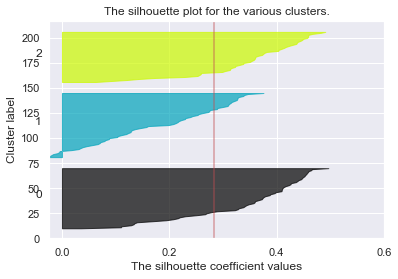

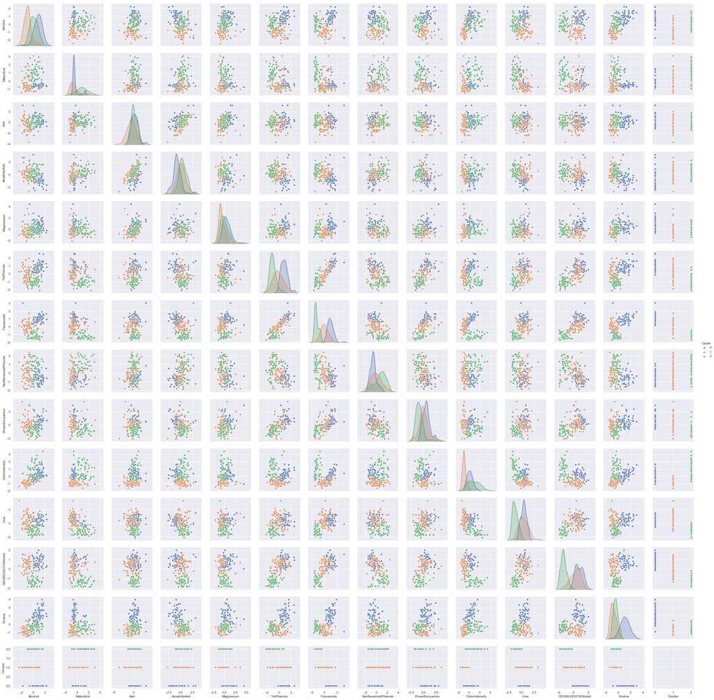

```python
import matplotlib.cm as cm
ss = skl.metrics.silhouette_samples(df_standardized, y_pred1)
fig, ax1 = plt.subplots(1)
ax1.set_xlim(ss.min(), ss.max()+0.1)
ax1.set_ylim(0, len(ss) + cluster_num * 10 + 10)
y_lower = 10
for i in range(cluster_num):
    ss_i = ss[y_pred1 == i]
    ss_i.sort()
    y_upper = y_lower + ss_i.shape[0]
    color = cm.nipy_spectral(float(i) / cluster_num)
    ax1.fill_betweenx(np.arange(y_lower, y_upper),
                          0, ss_i,
                          facecolor = color, edgecolor = color, alpha=0.7)
    ax1.axvline(skl.metrics.silhouette_score(df_standardized, y_pred1), color = 'r',
               linewidth = 0.3)
    ax1.text(-0.05, (y_upper + y_lower) / 2, i)
    y_lower = y_upper + 10
ax1.set_title("The silhouette plot for the various clusters.")
ax1.set_xlabel("The silhouette coefficient values")
ax1.set_ylabel("Cluster label")
ax1.set_xticks([0, 0.2, 0.4, 0.6])

tmp_df = df_standardized
tmp_df['Cluster'] = y_pred1

sns.pairplot(tmp_df, hue= 'Cluster')
plt.show()
```

### Exercise 8

- Create an "elbow chart" to determine the optimal number of clusters for df_standardized
- In the "elbow chart", the cluster inertia is the y axis and the number of clusters is the x axis
- Determine what the optimal number of clusters would be and explain why

```
1th inertia = 2399.4350282485875
2th inertia = 1680.8911421199657
3th inertia = 1267.8371282091557
4th inertia = 1179.672981500863
5th inertia = 1102.8225193041067
6th inertia = 1049.148194518134
7th inertia = 1002.8310072179347
8th inertia = 959.465171341615
9th inertia = 896.1772889045624
10th inertia = 850.7750246012014
3 is the optimal number of the clusters as we see an obvious elbow point with an coordinate of 3 on x-axis
```

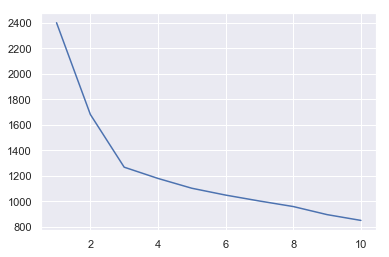

```python
inertia_i = []
for i in range(1, 11):
    km_i = KMeans(n_clusters = i, init = 'random').fit(df_standardized)
    print(str(i) + "th inertia = " + str(km_i.inertia_))
    inertia_i.append(km_i.inertia_)

plt.plot(np.arange(1,11), inertia_i)
plt.show
print("3 is the optimal number of the clusters as we see an obvious elbow point with \
an coordinate of 3 on x-axis ")
```

### Exercise 9

- Complete the Python code in myKMeans_Question.py
- The myKMeans function needs to call all the other functions defined in myKMeans_Question.py
- Import the myKMeans function from myKMeans_Question.py
- Conduct the cluster analysis for df_standardized using myKMeans and show the resulting k cluster centroids
- Compare the cluster centroids myKMeans returns and sklearn's built-in KMeans returns when using the same k and same random state

```python
%run myKMeans_Question.py
mk = myKMeans(df_standardized)
```

```
run_count = 0
run_count = 1
run_count = 2
run_count = 3
run_count = 4
run_count = 5
run_count = 6
```

```python
#myKMeans' result
mk
```

|  | Alcohol | MalicAcid | Ash | AlcalinityAsh | Magnesium | TotPhenols | Flavanoids | NonflavanoidPhenols | Proanthocyanins | ColorIntensity | Hue | OD280/OD315Diluted | Proline |
| --- | --- | --- | --- | --- | --- | --- | --- | --- | --- | --- | --- | --- | --- |
| 0 | -0.918325 | -0.395333 | -0.490502 | 0.163704 | -0.483216 | -0.071141 | 0.026589 | -0.037096 | 0.065095 | -0.895579 | 0.461408 | 0.282357 | -0.746074 |
| 1 | 0.173645 | 0.864250 | 0.187177 | 0.516844 | -0.064971 | -0.971065 | -1.206242 | 0.719152 | -0.771710 | 0.937816 | -1.156620 | -1.287226 | -0.400266 |
| 2 | 0.833365 | -0.301313 | 0.366173 | -0.606554 | 0.569222 | 0.887680 | 0.980165 | -0.561730 | 0.575837 | 0.170230 | 0.475347 | 0.775333 | 1.129645 |

```python
#sklearn's built-in KMeans' result. Sorted for comparison
skl_ctr = pd.DataFrame(km.cluster_centers_)
skl_ctr.columns = mk.columns
skl_ctr = skl_ctr.sort_values(by = 'Alcohol')
skl_ctr.set_index(np.arange(skl_ctr.shape[0]), inplace = True)
skl_ctr
```

|  | Alcohol | MalicAcid | Ash | AlcalinityAsh | Magnesium | TotPhenols | Flavanoids | NonflavanoidPhenols | Proanthocyanins | ColorIntensity | Hue | OD280/OD315Diluted | Proline |
| --- | --- | --- | --- | --- | --- | --- | --- | --- | --- | --- | --- | --- | --- |
| 0 | -0.918325 | -0.395333 | -0.490502 | 0.163704 | -0.483216 | -0.071141 | 0.026589 | -0.037096 | 0.065095 | -0.895579 | 0.461408 | 0.282357 | -0.746074 |
| 1 | 0.173645 | 0.864250 | 0.187177 | 0.516844 | -0.064971 | -0.971065 | -1.206242 | 0.719152 | -0.771710 | 0.937816 | -1.156620 | -1.287226 | -0.400266 |
| 2 | 0.833365 | -0.301313 | 0.366173 | -0.606554 | 0.569222 | 0.887680 | 0.980165 | -0.561730 | 0.575837 | 0.170230 | 0.475347 | 0.775333 | 1.129645 |

```python
#percentage difference of each dimension
#As shown, the percentage difference is negligible
abs((mk - skl_ctr) / skl_ctr) * 100
```

|  | Alcohol | MalicAcid | Ash | AlcalinityAsh | Magnesium | TotPhenols | Flavanoids | NonflavanoidPhenols | Proanthocyanins | ColorIntensity | Hue | OD280/OD315Diluted | Proline |
| --- | --- | --- | --- | --- | --- | --- | --- | --- | --- | --- | --- | --- | --- |
| 0 | 2.417930e-14 | 0.000000e+00 | 2.263444e-14 | 1.695475e-14 | 1.148786e-14 | 0.000000e+00 | 1.957238e-13 | 2.431706e-13 | 4.263858e-14 | 1.239671e-14 | 3.609249e-14 | 3.931982e-14 | 1.488087e-14 |
| 1 | 1.598412e-14 | 2.569216e-14 | 0.000000e+00 | 2.148083e-14 | 6.407965e-14 | 0.000000e+00 | 1.840796e-14 | 1.543795e-14 | 0.000000e+00 | 4.735354e-14 | 3.839542e-14 | 3.449970e-14 | 2.773716e-14 |
| 2 | 1.332217e-14 | 3.684616e-14 | 1.515981e-14 | 1.830379e-14 | 0.000000e+00 | 1.250701e-14 | 1.132690e-14 | 1.976435e-14 | 1.928017e-14 | 4.891437e-14 | 4.671214e-14 | 1.431930e-14 | 0.000000e+00 |

### Exercise 10

- Conduct another k-means cluster analysis on the un-standardized data df, excluding 'Cultivar', with k = 3 using randomly chosen initial centroids
- Assign cluster membership to each instance in the un-standardized dataset. Save the cluster membership labels of all the instances to a ndarray y_pred2
- Create a crosstab to compare the resulting clustering membership against the original label 'Cultivar' in df
- Create another crosstab to compare the clustering membership of Exercise 5 against the original label 'Cultivar' in df

```python
km_us = KMeans(n_clusters = 3, init = 'random').fit(df)
y_pred2 = km_us.labels_
df["Cluster"] = y_pred2
```

```python
#compare the resulting clustering membership against the original label 'Cultivar' in df
pd.crosstab(df.Cultivar ,df.Cluster)
#No strong pair-wise relationship is shown by the crosstab
```

| Cluster Cultivar | 0 | 1 | 2 |
| --- | --- | --- | --- |
| 1 | 0 | 45 | 13 |
| 2 | 50 | 1 | 20 |
| 3 | 19 | 0 | 29 |

```python
#compare the clustering membership of Exercise 5 against the original label 'Cultivar' in df
pd.crosstab(df.Cultivar, df_standardized.Cluster)
#From the crosstab, we can observe strong pair-wise relationships between Cluster and Cultivar, which are Cluster0-
#Cultivar3, Cluster1-Cultivar1, Cluster2-Cultivar2
```

| Cluster Cultivar | 0 | 1 | 2 |
| --- | --- | --- | --- |
| 1 | 0 | 50 | 8 |
| 2 | 3 | 3 | 65 |
| 3 | 48 | 0 | 0 |

### Exercise 11

+ Use sklearn's AgglomerativeClustering to conduct hierarchical clustering for df_standardized and identify three clusters + Assign cluster membership to each instance in the dataset. Save the cluster membership labels of all instances to a ndarray y_pred3

```python
from sklearn.cluster import AgglomerativeClustering as aggl
aggl_cluster = aggl(3).fit(df_standardized)
y_pred3 = aggl_cluster.labels_
df_std_11 = df_standardized
df_std_11['aggl_cluster'] = y_pred3
print(y_pred3)
```

```
[0 1 1 1 1 1 1 1 1 1 1 1 1 1 1 1 1 1 1 1 0 1 0 0 1 1 0 1 1 1 1 0 1 1 1 1 0
 0 1 1 0 1 0 0 1 1 1 1 1 1 1 1 1 1 1 1 1 1 0 2 2 0 0 0 0 0 0 2 1 2 0 0 1 0
 0 0 0 1 0 0 0 0 2 0 0 0 0 0 0 0 0 0 0 0 1 2 0 0 0 0 0 0 0 0 0 0 0 0 0 0 0
 0 0 0 0 0 0 2 0 0 1 0 0 0 0 0 0 0 0 2 2 2 2 2 2 2 2 2 2 2 2 2 2 2 2 2 2 2
 2 2 2 2 2 2 2 2 2 2 2 2 2 2 2 2 2 2 2 2 2 2 2 2 2 2 2 2 2]
```

### Exercise 12

Leverage the linkage and dendrogram functions of Scipy to create a dendrogram for the hierarchical clustering of df_standardized

```python
from scipy.cluster import hierarchy
```

```python
df_ddg = hierarchy.linkage(df_standardized)
```

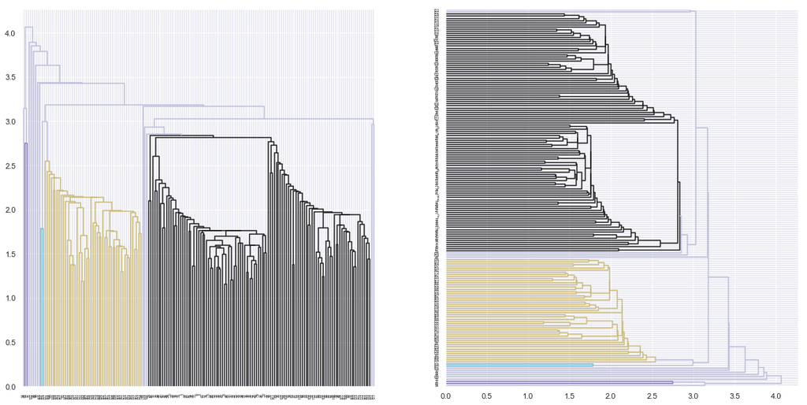

```python
hierarchy.set_link_color_palette(['m', 'c', 'y', 'k'])
fig, axes_2 = plt.subplots(1, 2, figsize = (20, 10))
dn1 = hierarchy.dendrogram(df_ddg, ax=axes_2[0], above_threshold_color='#bcbddc', orientation='top')
dn2 = hierarchy.dendrogram(df_ddg, ax=axes_2[1], above_threshold_color='#bcbddc', orientation='right')
```

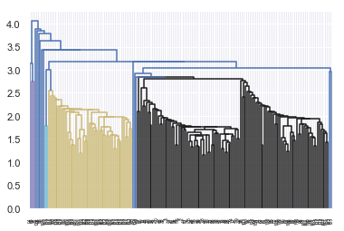

```python
dn3 = hierarchy.dendrogram(df_ddg)
```